#### The pitch maneuver

In the pitch maneuver, the pitch is varied in cycles lasting 20–30 s and the aircraft is allowed to climb and descend in response to the pitch changes while cycling above and below approximately the same average altitude. Typical changes in the vertical acceleration are about **±4** m/s<sup>**2**</sup> and the approximately sinusoidal vertical motion of the aircraft extends over about 6–10 cycles. This maneuver is best if flown where there is little vertical wind and steady horizontal wind.

The maneuver has two primary purposes:

If the wind-sensing system operates properly, it should produce a vertical wind that is unaffected by the vertical motion of the aircraft. The vertical wind **w** is the sum of the rate of climb of the aircraft (**w**<sub>**p**</sub>) and the upward component of the relative wind, and is given approximately by

[output not shown]

where **V** is the airspeed, **α** the angle of attack and **θ** the pitch angle. Usually the most difficult measurement is that of angle of attack because it is not measured directly but instead is determined from pressure measurements at ports on the nose radome. Requiring that there be no (or insignificant) correlation between the measured vertical wind and the induced rate of climb during the pitch maneuver is a stringent test of the validity of the empirical relationship used to determine **α**.

In addition, the relative timing among measurements affects the measurement of vertical wind during the pitch maneuver. Removing residual effects of the rate of climb on the vertical wind usually requires adjustment for the relative timing of the measurements, so this is an important check on the adjustments used to compensate for those timing errors. As commonly used, the variables entering (6) come from three different sources, each with its own clock to determine timing:

The airspeed and the pressure measurements entering **α** are provided by the central data-recording system (NIDAS) on the research aircraft.

In recent projects, the rate of climb of the aircraft has been measured by the GPS receiver.

The measurement of pitch is provided by the inertial system, with measurements normally transmitted to the aircraft data system after a delay that can range up to 80 ms.

In addition, the complete equation for the vertical wind involves additional transformations to compensate for the attitude of the aircraft, esp. the roll angle, and to determine the upward wind component relative to the Earth from the tilted coordinate system used by the aircraft. These usually have negligible effect except in turns, but those measurements have their own transmission delays that may differ from the pitch.

Because these two components of studies of pitch maneuvers are so closely related, they are combined in the QA application in a single type of plot, which shows the rate of climb with the measurement of vertical wind and lists the results of some critical comparisons:

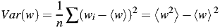

(7)

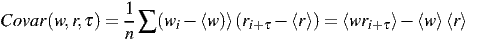

(8)

[output not shown]

where <> denotes the mean value and **τ**<sub>**max**</sub> is the time lag at which the covariance reaches a maximum. Even if the variance or standard deviation in the wind is small, a significant coefficient of determination will indicate that the induced maneuver has a significant effect on the measured vertical wind. Small **R**<sub>**max**</sub><sup>**2**</sup> is therefore a stringent test of the wind-measuring system.

A comparison between the standard deviation in vertical wind during the maneuver to that imposed on the rate of climb of the aircraft.

A comparison between the standard deviation in vertical wind during the maneuver and immediately before and immediately after the maneuver.

In addition, the tool supports adjustment of the relative timing among the measurements to determine what effects adjustments have on the performance during the pitch maneuver. An important consideration is that the relative timing corrections so determined may vary during a flight and from flight to flight; indeed, there are indications that they do. Nevertheless, these results provide guidance regarding representative values to use and the variability and uncertainty in those values.

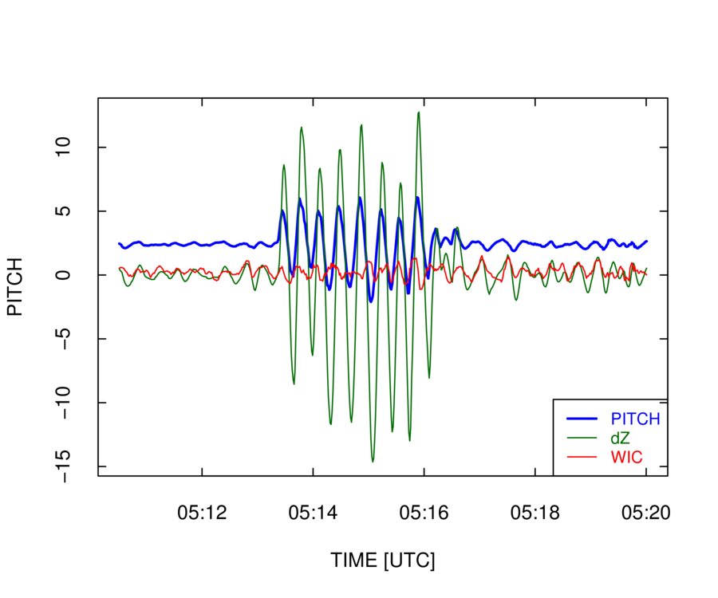

Figure 4: Pitch maneuver from the DEEPWAVE project, flight 15, 5:10:30–5:20:00 UTC. The variable "dZ" is the rate-of-climb of the aircraft.

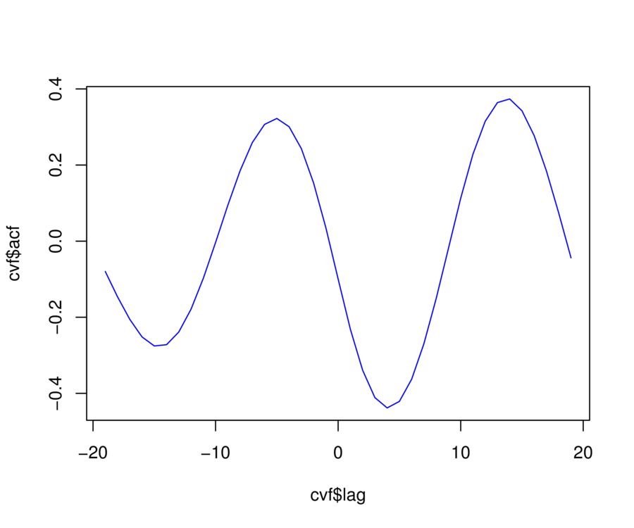

Figure 5: Cross-correlation function between vertical wind and rat-of-climb, as a function of lag.

Another meassure of the possible influence of the maneuver is to compare the standard deviation in WIC for times just before and just after the maneuver to that during the maneuver. In this case, the standard deviation for points in the interval of Fig. 4 but outside the interval listed above as the “central part” was 0.43, while that within the central part was 0.51, so this is reasonably consistent with the estimate of the effect of the maneuver in the preceding paragraph.